# JHU Capstone Milestone Report

## Introduction

The purpose of this milestone report is to report on analysis of a large corpus of text documents to discover the structure in the data and how words are put together. It will cover cleaning and analyzing text data, for future preparation of building and sampling from a predictive text model.

## Setup

```r
library(NLP)
library(tm)
library(wordcloud)
```

## Summarize the Data

```r
#Calculate the file sizes
fsb <- file.info("en_US.blogs.txt")$size / 1024^2
fsn <- file.info("en_US.news.txt")$size / 1024^2
fst <- file.info("en_US.twitter.txt")$size / 1024^2
file_sizes <- c(fsb,fsn,fst)

# Read in the data
blogs <- readLines("en_US.blogs.txt", skipNul=TRUE)
news <- readLines("en_US.news.txt", skipNul=TRUE)
twitter <- readLines("en_US.twitter.txt", skipNul=TRUE)

# Calculate the lengths of the datasets
lb <- length(blogs)
ln <- length(news)
lt <- length(twitter)
file_lengths <- c(lb,ln,lt)

# Calculate the longest lines
mb <- max(nchar(blogs))
mn <- max(nchar(news))
mt <- max(nchar(twitter))
max_char <- c(mb,mn,mt)

# Compile a data frame summarizing the data
frame_labels <- c('blogs','news','twitter')
data.summary <- data.frame(frame_labels,file_sizes,file_lengths,max_char)
data.summary
```

```
##   frame_labels file_sizes file_lengths max_char
## 1        blogs   200.4242       899288    40835
## 2         news   196.2775        77259     5760
## 3      twitter   159.3641      2360148      213
```

While the blogs dataset has the largest file size and the longest line, the twitter dataset has the highest number of entries (lines). The twitter dataset has the shortest lines due to the twitter website character limit.

We can further summarize the length of lines in each data source, with the mean, median, and quartiles.

```r
summary(nchar(blogs))
```

```
##    Min. 1st Qu.  Median    Mean 3rd Qu.    Max.
##     1.0    47.0   157.0   231.7   331.0 40840.0
```

```r
summary(nchar(news))
```

```
##    Min. 1st Qu.  Median    Mean 3rd Qu.    Max.
##       2     111     186     203     270    5760
```

```r
summary(nchar(twitter))
```

```
##    Min. 1st Qu.  Median    Mean 3rd Qu.    Max.
##     2.0    37.0    64.0    68.8   100.0   213.0
```

## Clean the Data

First we will create a sample subset of the data to explore, using 500 lines per dataset. Anything more would result in memory errors in future steps.

```r
sampleblogs <- sample(blogs,500)
samplenews <- sample(news,500)
sampletwitter <- sample(twitter,500)
sampleall <- c(sampleblogs,samplenews,sampletwitter)
```

Next, we will remove non-ASCII characters.

```r
# Convert string to vector of words
samptemp <- unlist(strsplit(sampleall, split=", "))

# Find indices of words with non-ASCII characters
nonascii <- grep("samptemp", iconv(samptemp, "latin1", "ASCII", sub="samptemp"))

# Subset original vector of words to exclude words with non-ASCII char
sampengl <- samptemp[-nonascii]

# Convert vector back to a string
sampleall <- paste(sampengl, collapse = ", ")
```

```r
samplecon <- Corpus(VectorSource(sampleall))
profane <- readLines("profanity.txt")
samplecon <- tm_map(samplecon, removeWords, profane)
samplecon <- tm_map(samplecon, removeNumbers)
samplecon <- tm_map(samplecon, removePunctuation)
samplecon <- tm_map(samplecon, removeWords, stopwords("en"))
samplecon <- tm_map(samplecon, stripWhitespace)
samplecon <- tm_map(samplecon, content_transformer(tolower))
```

## Explore the Data

Finally, we will explore the data to observe the most frequent words. We will explore n-grams and tokenization in the near future.

Create a document-term matrix

```r
dtm <- DocumentTermMatrix(samplecon)
dtm2 <- as.matrix(dtm)
```

Calculate the highest frequency words

```r
frequency <- colSums(dtm2)
frequency <- sort(frequency,decreasing=TRUE)
head(frequency)
```

```
##  the said  one will like just
##  223  143  114  102   96   91
```

Create a Word Cloud to display the most frequent words

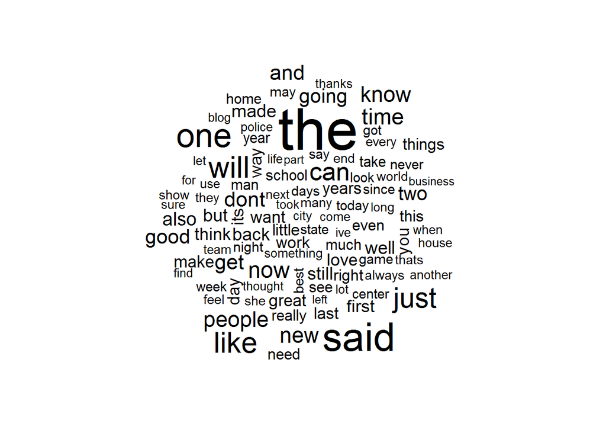

```r
words <- names(frequency)
wordcloud(words[1:100],frequency[1:100])
```